# Stablecoins — compare USDC, USDT and DAI transaction sizes and volumes

Isabella Flego

```r
library(usethis)
library(tidyverse)
library(httr2)

edit_r_environ()
api_key <- Sys.getenv("ETHERSCAN_API_KEY")
USDC = "0xa0b86991c6218b36c1d19d4a2e9eb0ce3606eb48"
USDT = "0xdac17f958d2ee523a2206206994597c13d831ec7"
DAI  = "0x6b175474e89094c44da98b954eedeac495271d0f"
```

```r
load  <- function(address)
  usdc <- request("https://api.etherscan.io/v2/api") |>
  req_url_query(
    chainid = 1,
    module = "account",
    action = "tokentx",
    contractaddress = address,
    startblock = 0,
    endblock = 99999999,
    page = 1,
    offset = 1000,
    sort = "asc",
    apikey = api_key
  ) |>
  req_perform() |>
  resp_body_json(simplifyVector = TRUE)

usdc <- load(USDC)
usdt <- load(USDT)
dai <- load(DAI)

write_rds(usdc, "data/usdc.rds")
write_rds(usdt, "data/usdt.rds")
write_rds(dai, "data/dai.rds")
```

```r
clean <- function(nome) {
  nome$result |>
  as_tibble() |>
  transmute(
    tokenName,
    value,
    amount = as.numeric(value) / 10^as.numeric(tokenDecimal),
    from,
    to,
    tokenSymbol,
    tokenDecimal
    )
}

usdc_df <- clean(usdc)
usdt_df <- clean(usdt)
dai_df  <- clean(dai)

usdc_df
```

```
## # A tibble: 1,000 × 7
##    tokenName value     amount from                to    tokenSymbol tokenDecimal
##    <chr>     <chr>      <dbl> <chr>               <chr> <chr>       <chr>
##  1 USDC      20000000    20   0x0000000000000000… 0x55… USDC        6
##  2 USDC      1000000      1   0x55fe002aeff02f77… 0x4d… USDC        6
##  3 USDC      1000000      1   0x55fe002aeff02f77… 0x4a… USDC        6
##  4 USDC      200000       0.2 0x55fe002aeff02f77… 0xe7… USDC        6
##  5 USDC      1000000      1   0x55fe002aeff02f77… 0x50… USDC        6
##  6 USDC      1000000      1   0x50eddb12e31ce6ae… 0x6f… USDC        6
##  7 USDC      100000       0.1 0x55fe002aeff02f77… 0xe7… USDC        6
##  8 USDC      400000       0.4 0x6f803466bcd17f44… 0x19… USDC        6
##  9 USDC      100000000  100   0x0000000000000000… 0x55… USDC        6
## 10 USDC      1000000      1   0x55fe002aeff02f77… 0xe1… USDC        6
## # ℹ 990 more rows
```

```r
usdt_df
```

```
## # A tibble: 1,000 × 7
##    tokenName  value       amount from             to    tokenSymbol tokenDecimal
##    <chr>      <chr>        <dbl> <chr>            <chr> <chr>       <chr>
##  1 Tether USD 100000000      100 0x36928500bc1dc… 0xc6… USDT        6
##  2 Tether USD 10000000        10 0xc6cde7c39eb2f… 0x2b… USDT        6
##  3 Tether USD 99900000000  99900 0x36928500bc1dc… 0xc6… USDT        6
##  4 Tether USD 10000000        10 0xc6cde7c39eb2f… 0x2b… USDT        6
##  5 Tether USD 20000000        20 0x2b2c9153acc40… 0x9f… USDT        6
##  6 Tether USD 10000000        10 0xc6cde7c39eb2f… 0x2b… USDT        6
##  7 Tether USD 10000000        10 0x2b2c9153acc40… 0x9f… USDT        6
##  8 Tether USD 100000000      100 0xc6cde7c39eb2f… 0x2b… USDT        6
##  9 Tether USD 100000000      100 0x2b2c9153acc40… 0x9f… USDT        6
## 10 Tether USD 20000000        20 0xc6cde7c39eb2f… 0x5a… USDT        6
## # ℹ 990 more rows
```

```r
dai_df
```

```
## # A tibble: 1,000 × 7
##    tokenName      value amount from               to    tokenSymbol tokenDecimal
##    <chr>          <chr>  <dbl> <chr>              <chr> <chr>       <chr>
##  1 Dai Stablecoin 0          0 0x000000000000000… 0xb9… DAI         18
##  2 Dai Stablecoin 0          0 0x000000000000000… 0xe9… DAI         18
##  3 Dai Stablecoin 0          0 0x000000000000000… 0x0c… DAI         18
##  4 Dai Stablecoin 0          0 0x000000000000000… 0x0c… DAI         18
##  5 Dai Stablecoin 0          0 0x000000000000000… 0x8d… DAI         18
##  6 Dai Stablecoin 0          0 0x000000000000000… 0x8d… DAI         18
##  7 Dai Stablecoin 0          0 0x000000000000000… 0x8d… DAI         18
##  8 Dai Stablecoin 0          0 0x000000000000000… 0x03… DAI         18
##  9 Dai Stablecoin 0          0 0x000000000000000… 0xa4… DAI         18
## 10 Dai Stablecoin 0          0 0x000000000000000… 0xad… DAI         18
## # ℹ 990 more rows
```

```r
# unione dei tre df
all_df <- bind_rows(usdc_df, usdt_df, dai_df)
all_df
```

```
## # A tibble: 3,000 × 7
##    tokenName value     amount from                to    tokenSymbol tokenDecimal
##    <chr>     <chr>      <dbl> <chr>               <chr> <chr>       <chr>
##  1 USDC      20000000    20   0x0000000000000000… 0x55… USDC        6
##  2 USDC      1000000      1   0x55fe002aeff02f77… 0x4d… USDC        6
##  3 USDC      1000000      1   0x55fe002aeff02f77… 0x4a… USDC        6
##  4 USDC      200000       0.2 0x55fe002aeff02f77… 0xe7… USDC        6
##  5 USDC      1000000      1   0x55fe002aeff02f77… 0x50… USDC        6
##  6 USDC      1000000      1   0x50eddb12e31ce6ae… 0x6f… USDC        6
##  7 USDC      100000       0.1 0x55fe002aeff02f77… 0xe7… USDC        6
##  8 USDC      400000       0.4 0x6f803466bcd17f44… 0x19… USDC        6
##  9 USDC      100000000  100   0x0000000000000000… 0x55… USDC        6
## 10 USDC      1000000      1   0x55fe002aeff02f77… 0xe1… USDC        6
## # ℹ 2,990 more rows
```

### domanda 1

In che modo differiscono le loro dimensioni di trasferimento?

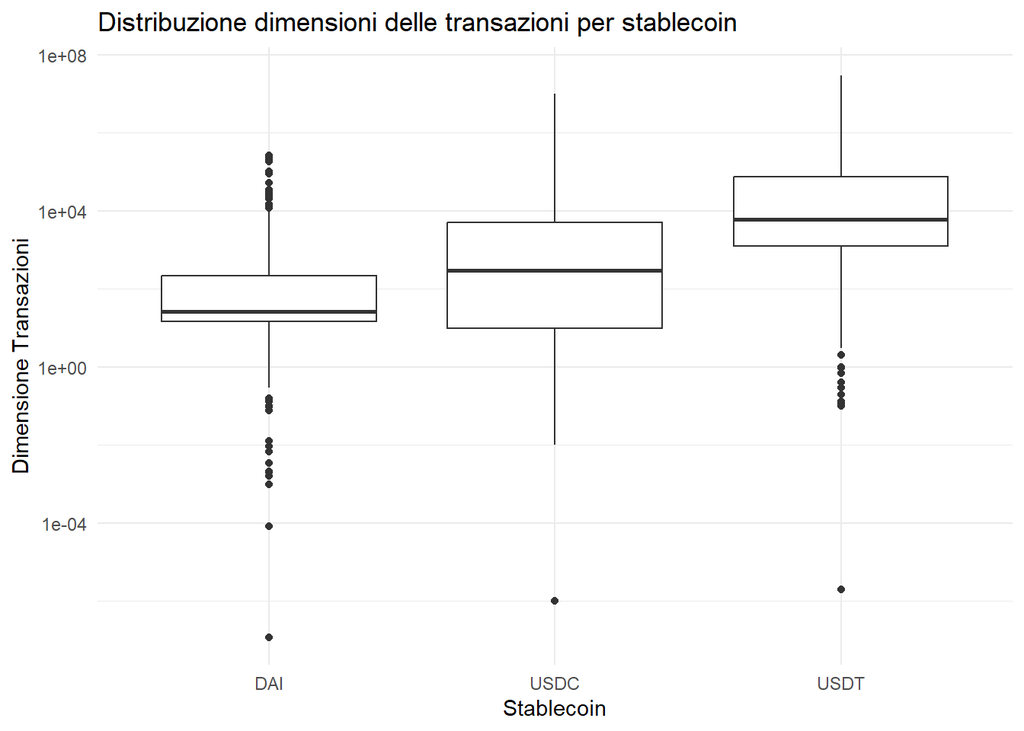

```r
ggplot(all_df, aes(x = tokenSymbol, y = amount)) +
  geom_boxplot() +
  scale_y_log10() +
  labs(
    title = "Distribuzione dimensioni delle transazioni per stablecoin",
    x = "Stablecoin",
    y = "Dimensione Transazioni"
  ) +
  theme_minimal()
```

Il boxplot mostra la distrubuzione della dimensione delle transazioni di DAI, USDC, USDT: DAI ha la mediana più bassa (attorno a $10^1$) e un intervallo interquartile piccolo; quindi la maggior parte delle sue transazioni sono di importi simili tra loro e non troppo elevati. UDSC invece ha come mediana un valore di circa $10^2$-$10^3$, ma la scatola è più ampia il che significa che c’è maggiore variabilità nei volumi nelle transazioni. USDT ha la mediana più alta, quasi di $10^4$ che indica la prevalenza di trasferimenti con importi superiori rispetto alle altre due stablecoin.

```r
statistics <- function(nome) {
  nome |>
    group_by(tokenSymbol) |>
    summarise (
      totale = sum(amount, na.rm = TRUE),
      media = mean(amount, na.rm = TRUE),
      mediana = median(amount, na.rm = TRUE),
      massimo = max(amount, na.rm = TRUE),
      minimo = min(amount, na.rm = TRUE)
    )
}

usdc_statistics <- statistics(usdc_df)
usdt_statistics <- statistics(usdt_df)
dai_statistics <- statistics(dai_df)

statistics_tot <- bind_rows(usdc_statistics, usdt_statistics, dai_statistics)
statistics_tot
```

```
## # A tibble: 3 × 6
##   tokenSymbol     totale   media mediana   massimo   minimo
##   <chr>            <dbl>   <dbl>   <dbl>     <dbl>    <dbl>
## 1 USDC        113577283. 113577.   300.  10000000  0
## 2 USDT        265176828. 265177.  6088.  30000000  0.000002
## 3 DAI           2623383.   2623.    20.0   269071. 0
```

La tabella conferma ciò che è stato osservato nel boxplot: la mediana cresce nettamente da DAI a USDC fino a USDT. Mentre DAI registra i valori più bassi e USDC ha valori intermedi, USDT registra anche la media e il massimo più elevati, a conferma della maggiore entità dei suoi trasferimenti.

### domanda 2

Quanto volume di transazioni genera ciascuna stablecoin?

```r
volume_tot <- statistics_tot |>
  select(tokenSymbol, totale)
volume_tot
```

```
## # A tibble: 3 × 2
##   tokenSymbol     totale
##   <chr>            <dbl>
## 1 USDC        113577283.
## 2 USDT        265176828.
## 3 DAI           2623383.
```

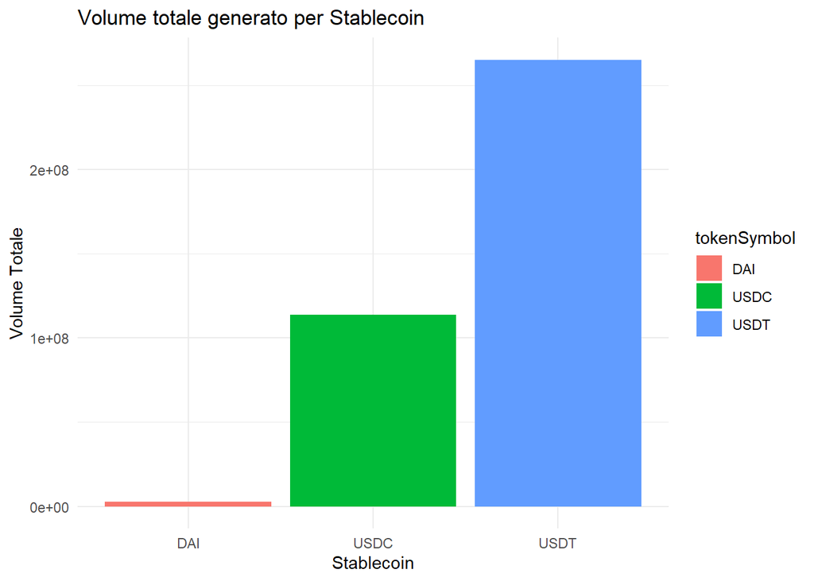

```r
ggplot(statistics_tot, aes(x = tokenSymbol, y = totale, fill = tokenSymbol)) +
  geom_col() +
  labs(
    title = "Volume totale generato per Stablecoin",
    x = "Stablecoin",
    y = "Volume Totale"
  ) +
  theme_minimal()
```

La tabella e il grafico a barre evidenziano la notevole differenza di volume generato tra le stablecoin: DAI, quasi impercettibile nel grafico, registra un valore di circa 2,62 milioni; USDC, a un livello intermedio, raggiunge circa 113,6 milioni; infine, USDT registra il volume massimo con oltre 265 milioni.